# Market Basket Analysis

Giovanni Del Piano

2025-04-25

# 1 **Introduzione**

In questo notebook utilizzeremo l’**algoritmo Apriori** per eseguire una **Market Basket Analysis**. Una Market Basket Analysis è una tecnica utilizzata dai grandi rivenditori per scoprire associazioni tra articoli.  
Funziona cercando combinazioni di articoli che si verificano frequentemente insieme nelle transazioni, fornendo informazioni utili a comprendere il comportamento di acquisto.  
Il risultato di questo tipo di analisi è, in termini semplici, un insieme di **regole** che possono essere interpretate come **“se accade questo, allora accade quello”**.  
Per ulteriori informazioni su questi argomenti, puoi consultare i seguenti link:

- [Market Basket Analysis](https://en.wikipedia.org/wiki/Affinity_analysis)
- [Algoritmo Apriori](https://en.wikipedia.org/wiki/Apriori_algorithm)
- [Apprendimento di regole di associazione](https://en.wikipedia.org/wiki/Association_rule_learning)

Per cominciare, è importante definire l’algoritmo Apriori, includendo alcuni concetti statistici (support, confidence, lift e conviction) per selezionare le regole più interessanti.  
Successivamente utilizzeremo un dataset contenente più di 6.000 transazioni provenienti da una panetteria per applicare l’algoritmo e scoprire combinazioni di prodotti acquistati insieme.  
Iniziamo!

# 2 **Regole di associazione**

L’algoritmo Apriori genera regole di associazione per un determinato dataset.  
Una regola di associazione implica che se un articolo A si verifica, allora anche l’articolo B si verifica con una certa probabilità.  
Vediamo un esempio:

| Transaction | Items |
| --- | --- |
| t1 | {T-shirt, Trousers, Belt} |
| t2 | {T-shirt, Jacket} |
| t3 | {Jacket, Gloves} |
| t4 | {T-shirt, Trousers, Jacket} |
| t5 | {T-shirt, Trousers, Sneakers, Jacket, Belt} |
| t6 | {Trousers, Sneakers, Belt} |
| t7 | {Trousers, Belt, Sneakers} |

Nella tabella sopra possiamo vedere sette transazioni provenienti da un negozio di abbigliamento.  
Ogni transazione mostra gli articoli acquistati. Possiamo rappresentare gli articoli come un **item set** nel modo seguente:

$$I=\{i_1, i_2,..., i_k\}$$

Nel nostro caso corrisponde a:

$$I=\{T\text- shirt, Trousers, Belt,
Jacket, Gloves, Sneakers\}$$

Una **transazione** è rappresentata dalla seguente espressione:

$$T=\{t_1, t_2,..., t_n\}$$

Ad esempio,

$$t_1=\{T\text- shirt, Trousers,
Belt\}$$

Una **regola di associazione** è quindi definita come un’implicazione nella forma:

$X \Rightarrow Y$, dove $X \subset I$, $Y \subset I$ e $X \cap Y = 0$

Ad esempio,

$$\{T\text- shirt, Trousers\} \Rightarrow
\{Belt\}$$

Nelle sezioni seguenti definiremo quattro metriche per misurare la bontà di una regola.

## 2.1 Support

Il support indica quanto frequentemente un certo itemset compare nel dataset.

$$supp(X \Rightarrow Y)=\dfrac{|X \cup
Y|}{n}$$

In altre parole, è il numero di transazioni che contengono sia $X$ che $Y$ diviso per il numero totale di transazioni.  
Le regole con un support troppo basso tendono a non essere utili. Vediamo alcuni esempi usando le transazioni del negozio di abbigliamento:

- $supp(T\text- shirt \Rightarrow Trousers)=\dfrac{3}{7}=43\%$
- $supp(Trousers \Rightarrow Belt)=\dfrac{4}{7}=57\%$
- $supp(T\text- shirt \Rightarrow Belt)=\dfrac{2}{7}=28\%$
- $supp(\{T\text- shirt, Trousers\} \Rightarrow \{Belt\})=\dfrac{2}{7}=28\%$

## 2.2 Confidence

Per una regola $X \Rightarrow Y$, la confidence mostra la percentuale di volte in cui $Y$ è stato acquistato insieme a $X$.  
È un’indicazione di quanto spesso la regola si è dimostrata vera.

$$conf(X \Rightarrow Y)=\dfrac{supp(X \cup
Y)}{supp(X)}$$

Ad esempio, la regola $T\text- shirt \Rightarrow Trousers$ ha confidence 3/4, il che significa che nel 75% delle transazioni contenenti una t-shirt vengono acquistati anche Trousers.  
Altri esempi:

- $conf(Trousers \Rightarrow Belt)=\dfrac{4/7}{5/7}=80\%$
- $conf(T\text- shirt \Rightarrow Belt)=\dfrac{2/7}{4/7}=50\%$
- $conf(\{T\text- shirt, Trousers\} \Rightarrow \{Belt\})=\dfrac{2/7}{3/7}=66\%$

## 2.3 Lift

Il lift di una regola è il rapporto tra il support osservato e quello atteso se $X$ e $Y$ fossero indipendenti, ed è definito come:

$$lift(X \Rightarrow Y)=\dfrac{supp(X \cup
Y)}{supp(X)supp(Y)}$$

Valori di lift più alti indicano associazioni più forti. Alcuni esempi:

- $lift(T\text- shirt \Rightarrow Trousers)=\dfrac{3/7}{(4/7)(5/7)}=1.05$
- $lift(Trousers \Rightarrow Belt)=\dfrac{4/7}{(5/7)(4/7)}=1.4$
- $lift(T\text- shirt \Rightarrow Belt)=\dfrac{2/7}{(4/7)(4/7)}=0.875$
- $lift(\{T\text- shirt, Trousers\} \Rightarrow \{Belt\})=\dfrac{2/7}{(3/7)(4/7)}=1.17$

## 2.4 Conviction

La conviction di una regola è definita come:

$$conv(X \Rightarrow
Y)=\dfrac{1-supp(Y)}{1-conf(X \Rightarrow Y)}$$

Può essere interpretata come il rapporto tra la frequenza attesa che $X$ si verifichi **senza** $Y$ (se fossero indipendenti), e la frequenza **osservata** delle previsioni sbagliate.  
Un valore elevato significa che il conseguente ($Y$) dipende fortemente dall’antecedente ($X$). Alcuni esempi:

- $conv(T\text- shirt \Rightarrow Trousers)=\dfrac{1-5/7}{1-3/4}=1.14$
- $conv(Trousers \Rightarrow Belt)=\dfrac{1-4/7}{1-4/5}=2.14$
- $conv(T\text- shirt \Rightarrow Belt)=\dfrac{1-4/7}{1-1/2}=0.86$
- $conv(\{T\text- shirt, Trousers\} \Rightarrow \{Belt\})=\dfrac{1-4/7}{1-2/3}=1.28$

Per ulteriori informazioni su queste misure, consulta [qui](https://en.wikipedia.org/wiki/Association_rule_learning).

## 2.5 Come funziona passo-passo l’algoritmo Apriori

- Trova tutti gli itemset frequenti singoli (con support ≥ soglia).
- Crea candidati di dimensione 2, 3, …, k combinando quelli frequenti trovati prima.
- Scarta quelli che contengono sottoinsiemi non frequenti.
- Ripeti finché non trovi più itemset candidati con supporto sufficiente.
- Genera regole di associazione da questi itemset frequenti, calcolando confidenza e lift.

## 2.6 Esempio semplice

Dataset:

T1: {pane, burro, latte}  
T2: {pane, burro}  
T3: {burro, latte}  
T4: {pane, latte}  
T5: {pane, burro, latte}

Supponiamo:

- Soglia di supporto: 60% (almeno in 3 su 5 transazioni)
1. **Itemset** {pane}, {burro}, {latte} → frequenti.
2. **Combiniamo**: {pane, burro}, {pane, latte}, {burro, latte} → Tutti hanno supporto ≥ 60%.
3. **Combiniamo**: {pane, burro, latte} → presente in T1 e T5 (2/5 = 40%) → scartato.
4. Dalle combinazioni valide generiamo regole:
- {pane}⇒{burro} con confidenza = support({pane, burro}) / support({pane})

✅ Vantaggi

- Intuitivo e facile da implementare.
- Ottimo per piccoli/medi dataset.

❌ Limiti

- Crescita esplosiva di combinazioni con dataset grandi.
- Richiede molte letture del dataset (costoso in termini computazionali).

🛠️ Quando usarlo

- Analisi delle vendite e promozioni mirate.
- Ottimizzazione layout nei supermercati.
- Suggerimenti di acquisto in e-commerce.

# 3 **Caricamento dei dati**

Per prima cosa dobbiamo caricare alcune librerie e importare i dati.  
Possiamo usare la funzione [`read.transactions()`](https://www.rdocumentation.org/packages/arules/versions/1.6-5/topics/read.transactions) del pacchetto [`arules`](https://cran.r-project.org/web/packages/arules/arules.pdf)  
per creare un oggetto di tipo `transactions`.

```r
# Load libraries
library(tidyverse) # data manipulation
library(arules) # mining association rules and frequent itemsets
library(arulesViz) # visualization techniques for association rules
library(knitr) # dynamic report generation
library(gridExtra) # provides a number of user-level functions to work with "grid" graphics
library(lubridate) # work with dates and times

# Read the data
trans <- read.transactions("BreadBasket_DMS.csv", format="single", cols=c(3,4), sep=",", rm.duplicates=TRUE)
```

Mostriamo i dati

## 3.1 Transaction object

```r
# Transaction object
trans
```

```
## transactions in sparse format with
##  6614 transactions (rows) and
##  104 items (columns)
```

## 3.2 Summary

```r
# Summary
summary(trans)
```

```
## transactions as itemMatrix in sparse format with
##  6614 rows (elements/itemsets/transactions) and
##  104 columns (items) and a density of 0.02008705
##
## most frequent items:
##  Coffee   Bread     Tea    Cake  Pastry (Other)
##    3188    2146     941     694     576    6272
##
## element (itemset/transaction) length distribution:
## sizes
##    1    2    3    4    5    6    7    8    9   10
## 2556 2154 1078  546  187   67   18    3    2    3
##
##    Min. 1st Qu.  Median    Mean 3rd Qu.    Max.
##   1.000   1.000   2.000   2.089   3.000  10.000
##
## includes extended item information - examples:
##                     labels
## 1               Adjustment
## 2 Afternoon with the baker
## 3                Alfajores
##
## includes extended transaction information - examples:
##   transactionID
## 1             1
## 2            10
## 3          1000
```

## 3.3 Glimpse

```r
# Glimpse
glimpse(trans)
```

```
## Formal class 'transactions' [package "arules"] with 3 slots
##   ..@ data       :Formal class 'ngCMatrix' [package "Matrix"] with 5 slots
##   ..@ itemInfo   :'data.frame':  104 obs. of  1 variable:
##   .. ..$ labels: chr [1:104] "Adjustment" "Afternoon with the baker" "Alfajores" "Argentina Night" ...
##   ..@ itemsetInfo:'data.frame':  6614 obs. of  1 variable:
##   .. ..$ transactionID: chr [1:6614] "1" "10" "1000" "1001" ...
```

## 3.4 Structure

```r
# Structure
str(trans)
```

```
## Formal class 'transactions' [package "arules"] with 3 slots
##   ..@ data       :Formal class 'ngCMatrix' [package "Matrix"] with 5 slots
##   .. .. ..@ i       : int [1:13817] 11 63 80 19 80 11 93 14 45 11 ...
##   .. .. ..@ p       : int [1:6615] 0 1 3 5 7 9 11 15 16 17 ...
##   .. .. ..@ Dim     : int [1:2] 104 6614
##   .. .. ..@ Dimnames:List of 2
##   .. .. .. ..$ : NULL
##   .. .. .. ..$ : NULL
##   .. .. ..@ factors : list()
##   ..@ itemInfo   :'data.frame':  104 obs. of  1 variable:
##   .. ..$ labels: chr [1:104] "Adjustment" "Afternoon with the baker" "Alfajores" "Argentina Night" ...
##   ..@ itemsetInfo:'data.frame':  6614 obs. of  1 variable:
##   .. ..$ transactionID: chr [1:6614] "1" "10" "1000" "1001" ...
```

# 4 **Dizionario dei Dati**

- `Date`. Variabile categorica che indica la data delle transazioni (formato YYYY-MM-DD). La colonna include date dal 30/10/2016 al 09/04/2017.
- `Time`. Variabile categorica che indica l’orario delle transazioni (formato HH:MM:SS).
- `Transaction`. Variabile quantitativa che ci permette di distinguere le transazioni. Le righe che condividono lo stesso valore in questo campo appartengono alla stessa transazione,  
  ed è per questo che il numero di transazioni è inferiore al numero di osservazioni.
- `Item`. Variabile categorica contenente i prodotti.

# 5 **Analisi Esplorativa dei Dati**

Prima di applicare l’algoritmo Apriori al dataset, mostreremo alcune visualizzazioni per comprendere meglio le transazioni.  
Ad esempio, possiamo usare la funzione `itemFrequencyPlot()` per creare un grafico a barre della frequenza degli item, al fine di osservare la distribuzione dei prodotti.

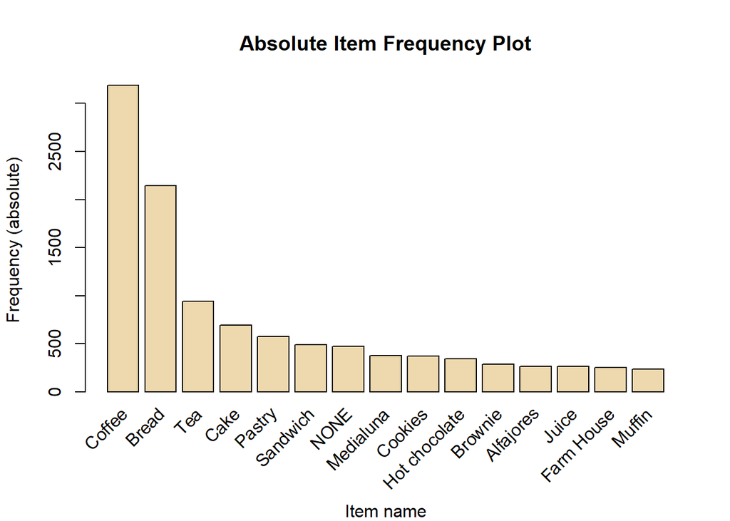

```r
# Absolute Item Frequency Plot
itemFrequencyPlot(trans, topN=15, type="absolute", col="wheat2",xlab="Item name",
                  ylab="Frequency (absolute)", main="Absolute Item Frequency Plot")
```

Il [`itemFrequencyPlot()`](https://www.rdocumentation.org/packages/arules/versions/1.6-5/topics/itemFrequencyPlot) ci consente di mostrare le frequenze relative o assolute.

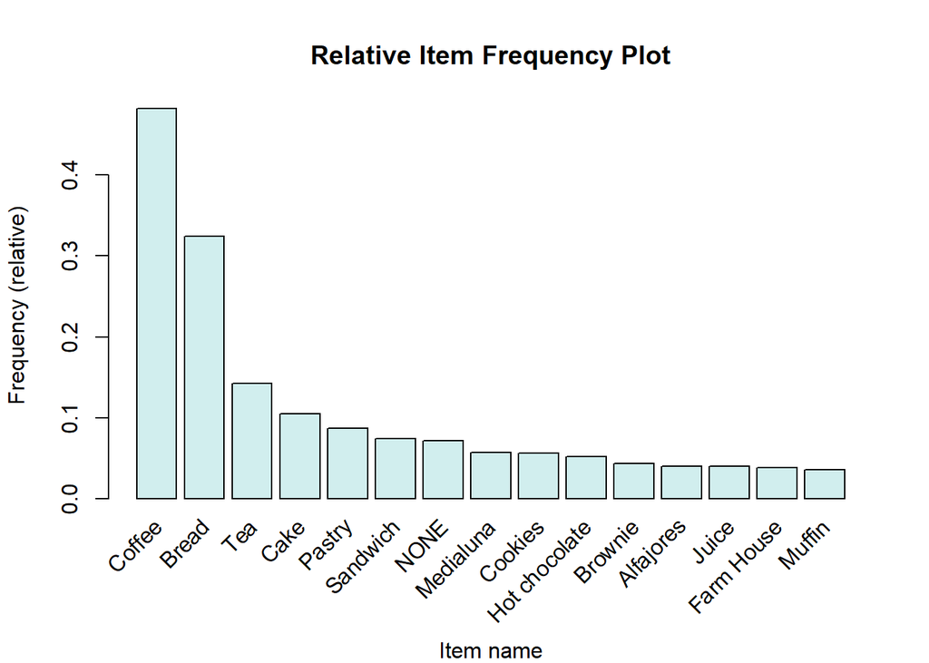

```r
# Relative Item Frequency Plot
itemFrequencyPlot(trans, topN=15, type="relative", col="lightcyan2", xlab="Item name",
                  ylab="Frequency (relative)", main="Relative Item Frequency Plot")
```

Il caffè è l’item più venduto seguito da pane e te, mostriamo qualche altra distribuzione per descrivere come si comportano le vendite durante l’arco della giornata. [`ggplot()`](https://www.rdocumentation.org/packages/ggplot2/versions/3.3.0/topics/ggplot) function.

- Transactions per mese
- Transactions per giorno della settimana
- Transactions per ora

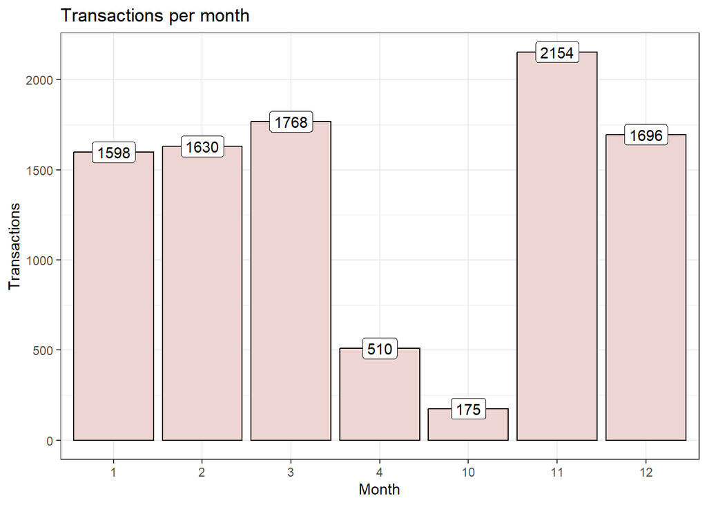

```r
# Load data
trans_csv <- read.csv("BreadBasket_DMS.csv")

# Visualization - Transactions per month
trans_csv %>%
  mutate(Month=as.factor(month(Date))) %>%
  group_by(Month) %>%
  summarise(Transactions=n_distinct(Transaction)) %>%
  ggplot(aes(x=Month, y=Transactions)) +
  geom_bar(stat="identity", fill="mistyrose2",
           show.legend=FALSE, colour="black") +
  geom_label(aes(label=Transactions)) +
  labs(title="Transactions per month") +
  theme_bw()
```

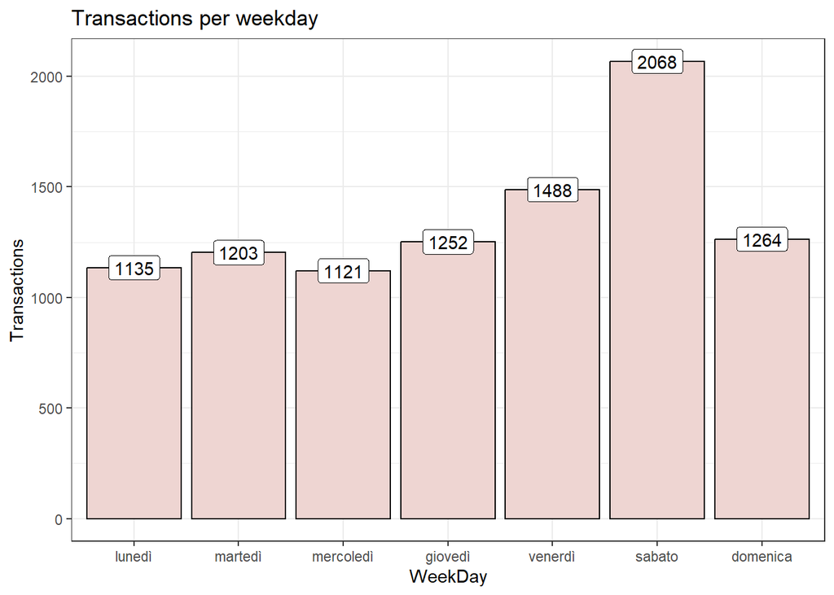

```r
# Visualization - Transactions per weekday
trans_csv %>%
  mutate(WeekDay=as.factor(weekdays(as.Date(Date)))) %>%
  group_by(WeekDay) %>%
  summarise(Transactions=n_distinct(Transaction)) %>%
  ggplot(aes(x=WeekDay, y=Transactions)) +
  geom_bar(stat="identity", fill="mistyrose2",
           show.legend=FALSE, colour="black") +
  geom_label(aes(label=Transactions)) +
  labs(title="Transactions per weekday") +
  scale_x_discrete(limits = c("lunedì", "martedì", "mercoledì", "giovedì",
                              "venerdì", "sabato", "domenica")) +
  theme_bw()
```

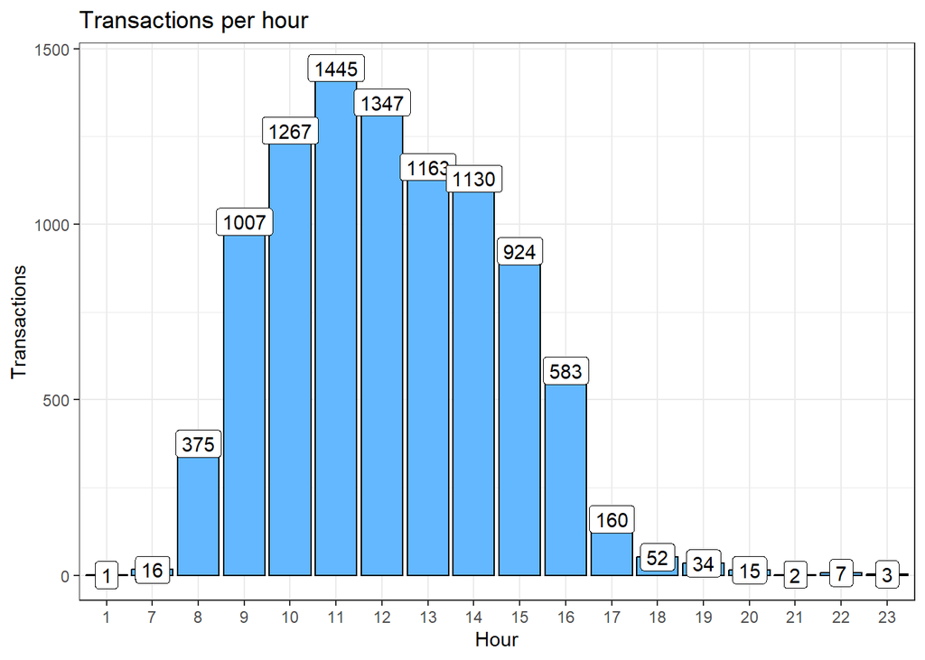

```r
# Visualization - Transactions per hour
trans_csv %>%
  mutate(Hour=as.factor(hour(hms(Time)))) %>%
  group_by(Hour) %>%
  summarise(Transactions=n_distinct(Transaction)) %>%
  ggplot(aes(x=Hour, y=Transactions)) +
  geom_bar(stat="identity", fill="steelblue1", show.legend=FALSE, colour="black") +
  geom_label(aes(label=Transactions)) +
  labs(title="Transactions per hour") +
  theme_bw()
```

# 6 **Apriori algorithm**

## 6.1 Scelta dei livelli di support e confidence

Il primo passo per creare un set di regole associative è determinare la soglia per i valori di support e confidence, Se settiamo questi valori troppo in basso, l’algoritmo ci metterà più tempo a girare e finiremo con l’avere moltissime regole, per lo più inutili. Quindi scegliamo più treshold per confrontarle tra loro

```r
# Support and confidence values
supportLevels <- c(0.1, 0.05, 0.01, 0.005)
confidenceLevels <- c(0.9, 0.8, 0.7, 0.6, 0.5, 0.4, 0.3, 0.2, 0.1)

# Empty integers
rules_sup10 <- integer(length=9)
rules_sup5 <- integer(length=9)
rules_sup1 <- integer(length=9)
rules_sup0.5 <- integer(length=9)

# Apriori algorithm with a support level of 10%
for (i in 1:length(confidenceLevels)) {

  rules_sup10[i] <- length(apriori(trans, parameter=list(sup=supportLevels[1],
                                   conf=confidenceLevels[i], target="rules")))

}

# Apriori algorithm with a support level of 5%
for (i in 1:length(confidenceLevels)){

  rules_sup5[i] <- length(apriori(trans, parameter=list(sup=supportLevels[2],
                                  conf=confidenceLevels[i], target="rules")))

}

# Apriori algorithm with a support level of 1%
for (i in 1:length(confidenceLevels)){

  rules_sup1[i] <- length(apriori(trans, parameter=list(sup=supportLevels[3],
                                  conf=confidenceLevels[i], target="rules")))

}

# Apriori algorithm with a support level of 0.5%
for (i in 1:length(confidenceLevels)){

  rules_sup0.5[i] <- length(apriori(trans, parameter=list(sup=supportLevels[4],
                                    conf=confidenceLevels[i], target="rules")))

}
```

Nei seguenti grafici osserviamo il numero di regole generate con un support level di 10, 5, 1 e 0.5 percento.

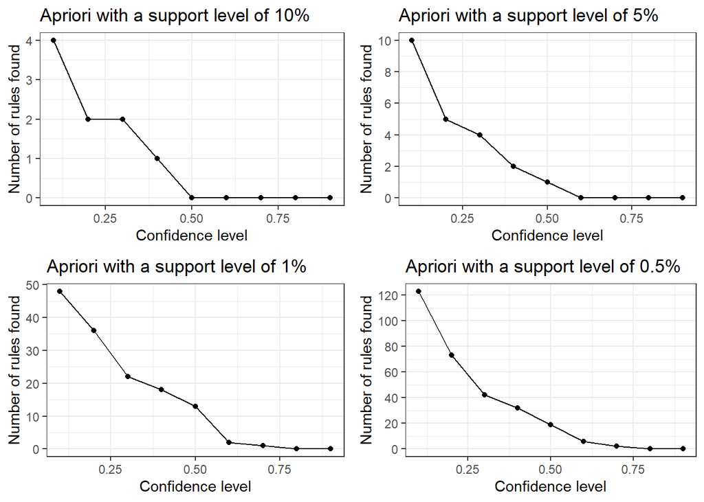

```r
# Number of rules found with a support level of 10%
plot1 <- qplot(confidenceLevels, rules_sup10, geom=c("point", "line"),
               xlab="Confidence level", ylab="Number of rules found",
               main="Apriori with a support level of 10%") +
  theme_bw()

# Number of rules found with a support level of 5%
plot2 <- qplot(confidenceLevels, rules_sup5, geom=c("point", "line"),
               xlab="Confidence level", ylab="Number of rules found",
               main="Apriori with a support level of 5%") +
  scale_y_continuous(breaks=seq(0, 10, 2)) +
  theme_bw()

# Number of rules found with a support level of 1%
plot3 <- qplot(confidenceLevels, rules_sup1, geom=c("point", "line"),
               xlab="Confidence level", ylab="Number of rules found",
               main="Apriori with a support level of 1%") +
  scale_y_continuous(breaks=seq(0, 50, 10)) +
  theme_bw()

# Number of rules found with a support level of 0.5%
plot4 <- qplot(confidenceLevels, rules_sup0.5, geom=c("point", "line"),
               xlab="Confidence level", ylab="Number of rules found",
               main="Apriori with a support level of 0.5%") +
  scale_y_continuous(breaks=seq(0, 130, 20)) +
  theme_bw()

# Subplot
grid.arrange(plot1, plot2, plot3, plot4, ncol=2)
```

Mostriamo i risultati sullo stesso grafico

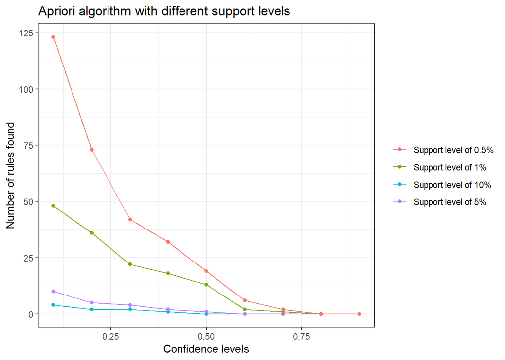

```r
# Data frame
num_rules <- data.frame(rules_sup10, rules_sup5, rules_sup1, rules_sup0.5, confidenceLevels)

# Number of rules found with a support level of 10%, 5%, 1% and 0.5%
ggplot(data=num_rules, aes(x=confidenceLevels)) +

  # Plot line and points (support level of 10%)
  geom_line(aes(y=rules_sup10, colour="Support level of 10%")) +
  geom_point(aes(y=rules_sup10, colour="Support level of 10%")) +

  # Plot line and points (support level of 5%)
  geom_line(aes(y=rules_sup5, colour="Support level of 5%")) +
  geom_point(aes(y=rules_sup5, colour="Support level of 5%")) +

  # Plot line and points (support level of 1%)
  geom_line(aes(y=rules_sup1, colour="Support level of 1%")) +
  geom_point(aes(y=rules_sup1, colour="Support level of 1%")) +

  # Plot line and points (support level of 0.5%)
  geom_line(aes(y=rules_sup0.5, colour="Support level of 0.5%")) +
  geom_point(aes(y=rules_sup0.5, colour="Support level of 0.5%")) +

  # Labs and theme
  labs(x="Confidence levels", y="Number of rules found",
       title="Apriori algorithm with different support levels") +
  theme_bw() +
  theme(legend.title=element_blank())
```

Analizziamo i risultati:

- **Livello di support del 10%**. Identifichiamo solo poche regole con livelli di confidence molto bassi. Questo significa che non ci sono associazioni relativamente frequenti nel nostro dataset.  
  Non possiamo scegliere questo valore, le regole risultanti non sono rappresentative.
- **Livello di support del 5%**. Identifichiamo solo una regola con una confidence di almeno il 50%. Sembra che dobbiamo cercare livelli di support inferiori al 5% per ottenere un numero maggiore  
  di regole con una confidence ragionevole.
- **Livello di support dell’1%**. Iniziamo a ottenere decine di regole, di cui 13 hanno una confidence di almeno il 50%.
- **Livello di support dello 0.5%**. Troppo elevato il numero di regole da analizzare!

In sintesi, useremo un **livello di support dell’1%** e un **livello di confidence del 50%**.

## 6.2 Esecuzione

Eseguiamo l’algoritmo Apriori con i valori ottenuti nella sezione precedente.

```r
# Apriori algorithm execution with a support level of 1% and a confidence level of 50%
rules_sup1_conf50 <- apriori(trans, parameter=list(sup=supportLevels[3],
                             conf=confidenceLevels[5], target="rules"))
```

Le regole di associazione sono le seguenti

```r
# Inspect association rules
inspect(rules_sup1_conf50)
```

```
##      lhs                 rhs      support    confidence coverage   lift
## [1]  {Tiffin}         => {Coffee} 0.01058361 0.5468750  0.01935289 1.134577
## [2]  {Spanish Brunch} => {Coffee} 0.01406108 0.6326531  0.02222558 1.312537
## [3]  {Scone}          => {Coffee} 0.01844572 0.5422222  0.03401875 1.124924
## [4]  {Toast}          => {Coffee} 0.02570305 0.7296137  0.03522830 1.513697
## [5]  {Alfajores}      => {Coffee} 0.02237678 0.5522388  0.04052011 1.145705
## [6]  {Juice}          => {Coffee} 0.02131842 0.5300752  0.04021772 1.099723
## [7]  {Hot chocolate}  => {Coffee} 0.02721500 0.5263158  0.05170850 1.091924
## [8]  {Medialuna}      => {Coffee} 0.03296039 0.5751979  0.05730269 1.193337
## [9]  {Cookies}        => {Coffee} 0.02978530 0.5267380  0.05654672 1.092800
## [10] {NONE}           => {Coffee} 0.04172966 0.5810526  0.07181736 1.205484
## [11] {Sandwich}       => {Coffee} 0.04233444 0.5679513  0.07453886 1.178303
## [12] {Pastry}         => {Coffee} 0.04868461 0.5590278  0.08708800 1.159790
## [13] {Cake}           => {Coffee} 0.05654672 0.5389049  0.10492894 1.118042
##      count
## [1]   70
## [2]   93
## [3]  122
## [4]  170
## [5]  148
## [6]  141
## [7]  180
## [8]  218
## [9]  197
## [10] 276
## [11] 280
## [12] 322
## [13] 374
```

Come si interpretano queste regole?

- Il 52% dei clienti che ha acquistato una cioccolata calda ha acquistato anche un caffè.
- Il 63% dei clienti che ha acquistato uno *spanish brunch* ha acquistato anche un caffè.
- Il 73% dei clienti che ha acquistato un toast ha acquistato anche un caffè.

E così via. Sembra che in questa panetteria ci siano molti amanti del caffè!

## 6.3 Visualizzazione delle regole di associazione

Useremo il pacchetto `arulesViz` per creare le visualizzazioni. La seguente visualizzazione mostra le regole sottoforma di grafo con gli item ai vertici e le regole rappresentate da i vertici connessi agli item con gli archi.

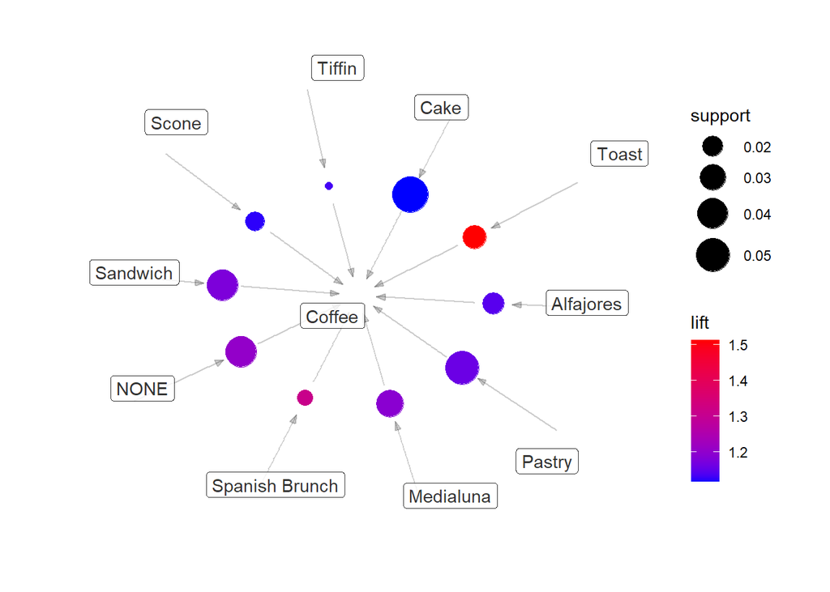

```r
# Graph (default layout)
plot(rules_sup1_conf50, method="graph", shading="lift", control = list(
    edges = ggraph::geom_edge_link(
      end_cap = ggraph::circle(4, "mm"),
      start_cap = ggraph::circle(4, "mm"),
      color = "black",
      arrow = arrow(length = unit(2, "mm"), angle = 20, type = "closed"),
      alpha = .2
    ),
    nodes = ggraph::geom_node_point(aes_string(size = "support", color = "lift")),
    nodetext = ggraph::geom_node_label(aes_string(label = "label"), alpha = .8, repel = TRUE)
  ),
  limit = 10
  ) +
  scale_color_gradient(low = "blue", high = "red") +
  scale_size(range = c(2, 10))
```

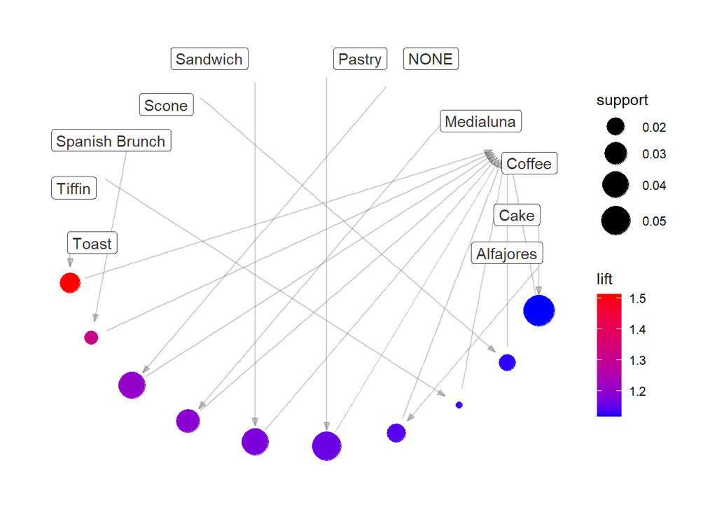

```r
# Graph (circular layout)
plot(rules_sup1_conf50, method = "graph", control = list(layout = "in_circle",
      edges = ggraph::geom_edge_link(
      end_cap = ggraph::circle(4, "mm"),
      start_cap = ggraph::circle(4, "mm"),
      color = "black",
      arrow = arrow(length = unit(2, "mm"), angle = 20, type = "closed"),
      alpha = .2
    ),
    nodes = ggraph::geom_node_point(aes_string(size = "support", color = "lift")),
    nodetext = ggraph::geom_node_label(aes_string(label = "label"), alpha = .8, repel = TRUE)
  ),
  limit = 10
  ) +
  scale_color_gradient(low = "blue", high = "red") +
  scale_size(range = c(2, 10))
```

# 7 **Esercizi**

In questa sezione puoi mettere alla prova i concetti appresi durante questo kernel rispondendo al seguente questionario. Buona fortuna!

- Fai un esempio in cui si può applicare l’algoritmo Apriori.
- Calcola il support della regola $Trousers \Rightarrow Jacket$ utilizzando le transazioni del negozio di abbigliamento. Interpreta il risultato.
- Calcola la confidence della regola $T\text- shirt \Rightarrow Jacket$ utilizzando le transazioni del negozio di abbigliamento. Interpreta il risultato.
- Calcola il lift della regola $Trousers \Rightarrow Sneakers$ utilizzando le transazioni del negozio di abbigliamento. Interpreta il risultato.
- Calcola la conviction della regola $T\text- shirt \Rightarrow Belt$ utilizzando le transazioni del negozio di abbigliamento. Interpreta il risultato.
- Calcola le quattro metriche (support, confidence, lift e conviction) della regola $\{T\text- shirt, Trousers\} \Rightarrow \{Jacket\}$ utilizzando le transazioni del negozio di abbigliamento. Interpreta i risultati.
- Cosa succede quando si diminuisce il livello di support? Perché?
- Cosa succede quando si aumenta il livello di confidence? Perché?
- Quante regole vengono generate con un livello di support dello 0.5% e un livello di confidence del 20%? (puoi usare le visualizzazioni precedenti)
- Utilizzando il dataset precedente, esegui l’algoritmo Apriori con un support del 5% e una confidence del 10%. Le regole ottenute sono interessanti? Perché?
- Quali raccomandazioni daresti al proprietario della panetteria?

Hai superato il test?

# 8 **Conclusioni**

In questo kernel abbiamo imparato a conoscere l’algoritmo Apriori, uno degli algoritmi più utilizzati nel data mining. Abbiamo rivisto alcuni concetti statistici  
(support, confidence, lift e conviction) per selezionare regole interessanti, abbiamo scelto i valori appropriati per eseguire l’algoritmo e infine visualizzato le regole di associazione risultanti.